# Soccer Project

Keaton Moyer

11/19/17

*Source file* ⇒ Soccer_Stat_Project.Rmd  
The source of the dataset of english results from 1888-2016 is from https://github.com/jalapic

```r
#Data Input

england<-england

England<-england %>%
  select(Date,Season,home,visitor,FT,hgoal,vgoal,totgoal,tier,goaldif) %>%
  mutate(result=ifelse(hgoal==vgoal,"D",
                ifelse(hgoal>vgoal,"H",
                ifelse(hgoal<vgoal,"V","NA")))) %>%
  filter(tier== 1)
```

```r
#Premier League Tables
  #Creates individual league tables from each season in Years

#This makes sure when rerunning code that Total does not have anything to start with
Total=NULL

#The time frame beginning and end for the loop to process
Years=c(1888:2016)

#For loop that creates each Final season table(Standings)
for (time in Years) {

Year=time
AssignName=paste("PremSeason",Year,sep = "")
SeasonTable= maketable(England,Season = time,tier = 1,pts = 3)
SeasonTable$Season=c(rep(time,nrow(SeasonTable)))#Creating a variable "Season" based on the year at the start of the season e.g. 2016-2017 would be 2016
SeasonTable$NTeam <- c(rep(nrow(SeasonTable),nrow(SeasonTable)))#Creating a variable "NTeam" is the number of teams in the league that season
assign(AssignName,SeasonTable)

#creating one massive data set of each season
Total=rbind(Total,SeasonTable)
}

#Changing the letter case of the column
Total<-Total %>%
  mutate(Pos=as.numeric(Pos)) %>%
  rename.vars(from = "team",to="Team")
```

```r
#This creates a dataset that has the number of seasons a team has played in the premier league
Nseason<-Total %>%
  group_by(Team) %>%
  summarise(NSeasons=n())

#This creates a dataset filtering out the teams that were relegated based on research of the teams relegated in that season
Relegated<-Total %>%
     filter((Total$Pos > 16) & (Total$Season > 1897) & (Total$Season < 1904)  |
           (Total$Pos > 18) & (Total$Season > 1904) & (Total$Season < 1915) |
           (Total$Pos > 20) & (Total$Season > 1918) & (Total$Season < 1973) |
           (Total$Pos > 19) & (Total$Season > 1972) & (Total$Season < 1987) |
           (Total$Pos > 18) & (Total$Season == 1987) |
           (Total$Pos > 17) & (Total$Season > 1987) & (Total$Season < 1990) |
           (Total$Pos > 18) & (Total$Season == 1990) |
           (Total$Pos > 19) & (Total$Season > 1990) & (Total$Season < 1995) |
           (Total$Pos > 17) & (Total$Season > 1994)) %>%
  group_by(Team) %>% tally() %>%
  rename.vars(from = "n",to="Relegated")

#This creates a dataset filtering out the teams that have won (finished 1st) the league
Champions<-Total %>%
  filter(Pos ==1) %>%
  group_by(Team) %>%
  tally() %>%
  rename.vars(from = "n",to="Champions")

#This merges the Stadiums information with relegations, and championships
Combination<-left_join(StadiumsPrem,Relegated,by="Team") %>%
  left_join(Champions,by="Team") %>% left_join(Nseason,by="Team")

Combination[is.na(Combination)] <- 0

Combination<-Combination %>%
  mutate(RelegatedPercentage = as.numeric(Relegated/NSeasons))

Combination$Relcontent<- paste0("Relegated: ",Combination$Relegated,
                               "<br>","Total Seasons: ", Combination$NSeasons,
                               "<br>","Rel Percent: ",
                               paste(round(100*Combination$RelegatedPercentage,
                                                        2), "%", sep=""))
```

```r
#aesthetics
  #Creates the graph, pins, and color palette

#Soccerball marker for pins on maps
soccerball <- makeAwesomeIcon(
  icon='fa-futbol-o',
  iconColor = 'Black',
  library='fa',
  markerColor = 'white')

#The dark map background
m<- leaflet(Combination) %>%
  addTiles() %>%
  addProviderTiles(providers$CartoDB.DarkMatter)

#setting a red palette of scale for map
pal <- colorNumeric(
  palette = "Reds",
  domain = Combination$Relegated)
```

## Teams

This map illustrates all the football (soccer) teams in England and Wales that have competed in the Top Division from 1888 to 2016. Each pin gives information on the team’s stadium and capacity.

```r
#This will display map with each pin referring to an individual club
#The pin, when clicked on, will display a pop up of the Team, Stadium, and Capacity

m %>%
  addAwesomeMarkers(lng = Combination$Longitude,lat = Combination$Latitude,
                    icon = soccerball,
                    popup = Combination$content,
                    label = Combination$Team)
```

[interactive chart not shown]

## Relegation

This map illustrates how often teams have been relegated from the English top division into the second division.

```r
#This will display map with each dot referring to an individual club
#The color of the dot visualizes how many times the club was relegated
#The dot, when clicked on, will display a pop up of the Number of times a team was relegated

m %>% addCircles(lng = Combination$Longitude,lat = Combination$Latitude,weight = 1,
                  radius = 5000,
                  label = ~Combination$Team,
                  popup = Combination$Relcontent,
                  color = ~pal(Combination$Relegated),
                  fillOpacity = 1)%>%
   addLegend("bottomright", pal = pal, values = ~Combination$Relegated,
             title = "Relegations from</br> Top Division",
             opacity = 1)
```

[interactive chart not shown]

## Champions

From being in the bottom to being on top. This map shows how often teams have won the division. The size of the circle is directly related to how many times the team won.

```r
#This will display map with each circle referring to an individual club
#The size of the circle visualizes how many times the club were crowned champions
#The circle, when clicked on, will display a pop up of the Number of times a team was crowned a champion

m %>% addCircleMarkers(lng = Combination$Longitude,lat = Combination$Latitude,weight = 1,
                       radius = Combination$Champions*2.5,label = ~Combination$Team,
                       popup = as.character(Combination$Champions))
```

[interactive chart not shown]

# Historically Big Clubs

Englands “Big Six” have been dominating the headlines and titles recently. These graphs contain the “Big Six” of Manchester United, Manchester City, Tottenham, Liverpool, Chelsea, and Arsenal with the addition of Everton who was one of the original teams in England and often competetive. These graphs show these seven clubs final league position over the years.

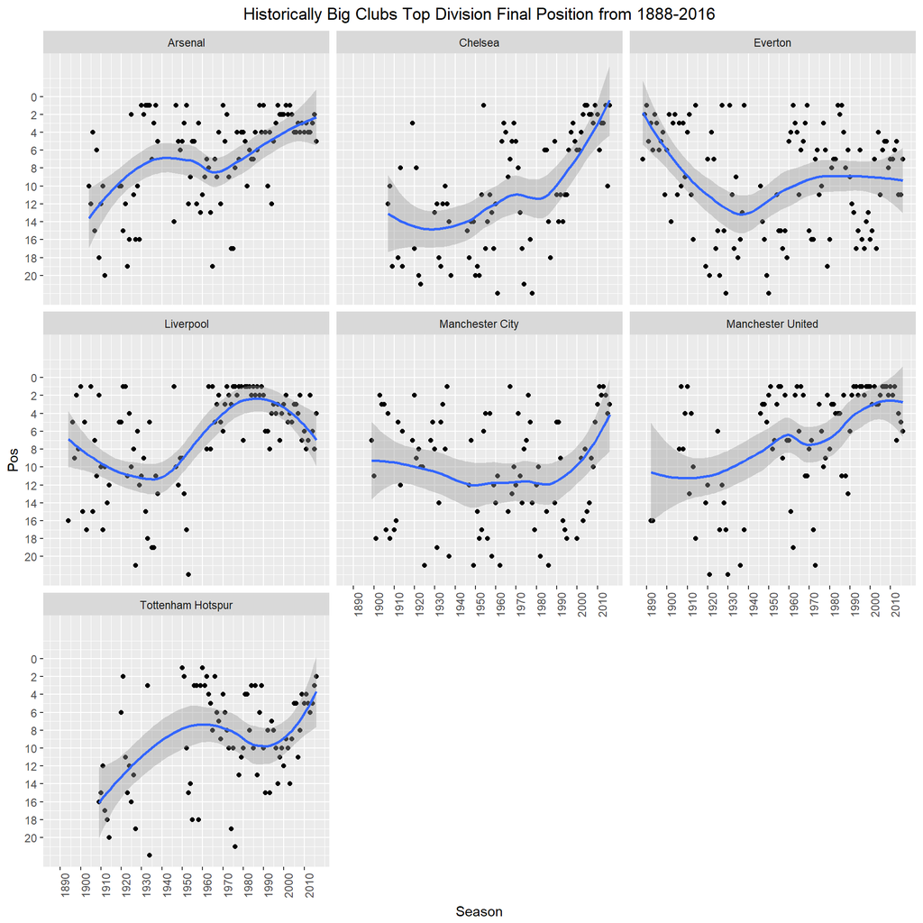

```r
Historic<-Total %>%
  filter(Team %in% c("Manchester United","Manchester City","Chelsea","Arsenal","Everton","Liverpool","Tottenham Hotspur"))

ggplot(data=Historic,aes(x=Season,y=Pos))+
  geom_point()+facet_wrap(~Team,ncol=3) +
  stat_smooth(method=loess)+
  ggtitle("Historically Big Clubs Top Division Final Position from 1888-2016") +
  theme(plot.title = element_text(hjust = 0.5))+
  scale_x_continuous(breaks = round(seq(1890, 2010, by = 10),1))+
  theme(axis.text.x=element_text(angle=90,hjust=1))+
  scale_y_reverse(breaks = round(seq(0, 20, by = 2),1))
```